# hw2_sol

Danielle LaVine

1/25/2022

```r
knitr::opts_chunk$set(echo = TRUE, cache = TRUE, cache.lazy = FALSE)
library(tidyverse)
library(data.table)
library(lubridate)
```

```r
os <- sessionInfo()$running
if (str_detect(os, "Linux")) {
  mimic_path <- "/mnt/mimiciv/1.0"
} else if (str_detect(os, "macOS")) {
  mimic_path <- "/Users/huazhou/Documents/Box Sync/MIMIC/mimic-iv-1.0"
}
```

In this exercise, we use tidyverse (ggpot2, dplyr, etc) to explore the [MIMIC-IV](https://mimic.mit.edu/docs/iv/) data introduced in [homework 1](https://ucla-biostat-203b.github.io/2022winter/hw/hw1/hw1.html) and to build a cohort of ICU stays.

```r
# tree -s -L 2 /Users/huazhou/Documents/Box\ Sync/MIMIC/mimic-iv-1.0
system(str_c("tree -s -L 2 ", shQuote(mimic_path)), intern = TRUE)
```

```
##  [1] "/mnt/mimiciv/1.0"
##  [2] "├── [       4096]  core"
##  [3] "│   ├── [   17208966]  admissions.csv.gz"
##  [4] "│   ├── [        606]  index.html"
##  [5] "│   ├── [    2955582]  patients.csv.gz"
##  [6] "│   └── [   53014503]  transfers.csv.gz"
##  [7] "├── [       4096]  hosp"
##  [8] "│   ├── [     430049]  d_hcpcs.csv.gz"
##  [9] "│   ├── [   29531152]  diagnoses_icd.csv.gz"
## [10] "│   ├── [     863239]  d_icd_diagnoses.csv.gz"
## [11] "│   ├── [     579998]  d_icd_procedures.csv.gz"
## [12] "│   ├── [      14898]  d_labitems.csv.gz"
## [13] "│   ├── [   11684062]  drgcodes.csv.gz"
## [14] "│   ├── [  515763427]  emar.csv.gz"
## [15] "│   ├── [  476252563]  emar_detail.csv.gz"
```

[output cut: 24 more lines]

## Q1. `read.csv` (base R) vs `read_csv` (tidyverse) vs `fread` (data.table)

There are quite a few utilities in R for reading plain text data files. Let us test the speed of reading a moderate sized compressed csv file, `admissions.csv.gz`, by three programs: `read.csv` in base R, `read_csv` in tidyverse, and `fread` in the popular data.table package.

Which function is fastest? Is there difference in the (default) parsed data types? (Hint: R function `system.time` measures run times.)

For later questions, we stick to the tidyverse.

```r
system.time(read.csv(str_c(mimic_path, '/core/admissions.csv.gz')))
```

```
##    user  system elapsed
##  43.884   0.244  46.267
```

```r
system.time(read_csv(str_c(mimic_path, '/core/admissions.csv.gz')))
```

```
##    user  system elapsed
##   3.665   0.277  11.625
```

```r
system.time(fread(str_c(mimic_path, '/core/admissions.csv.gz')))
```

```
##    user  system elapsed
##   1.468   0.125   2.047
```

## Q2. ICU stays

`icustays.csv.gz` (https://mimic.mit.edu/docs/iv/modules/icu/icustays/) contains data about Intensive Care Units (ICU) stays. The first 10 lines are

```r
system(
  str_c(
    "zcat < ",
    shQuote(str_c(mimic_path, "/icu/icustays.csv.gz")),
    " | head"
    ),
  intern = TRUE
)
```

```
##  [1] "subject_id,hadm_id,stay_id,first_careunit,last_careunit,intime,outtime,los"
##  [2] "17867402,24528534,31793211,Trauma SICU (TSICU),Trauma SICU (TSICU),2154-03-03 04:11:00,2154-03-04 18:16:56,1.5874537037037035"
##  [3] "14435996,28960964,31983544,Trauma SICU (TSICU),Trauma SICU (TSICU),2150-06-19 17:57:00,2150-06-22 18:33:54,3.025625"
##  [4] "17609946,27385897,33183475,Trauma SICU (TSICU),Trauma SICU (TSICU),2138-02-05 18:54:00,2138-02-15 12:42:05,9.741724537037038"
##  [5] "18966770,23483021,34131444,Trauma SICU (TSICU),Trauma SICU (TSICU),2123-10-25 10:35:00,2123-10-25 18:59:47,0.35054398148148147"
##  [6] "12776735,20817525,34547665,Neuro Stepdown,Neuro Stepdown,2200-07-12 00:33:00,2200-07-13 16:44:40,1.6747685185185184"
##  [7] "10215159,24283593,34569476,Trauma SICU (TSICU),Trauma SICU (TSICU),2124-09-20 15:05:29,2124-09-21 22:06:58,1.2926967592592593"
##  [8] "14489052,26516390,35056286,Trauma SICU (TSICU),Trauma SICU (TSICU),2118-10-26 10:33:56,2118-10-26 20:28:10,0.4126620370370371"
##  [9] "15914763,28906020,36909804,Trauma SICU (TSICU),Trauma SICU (TSICU),2176-12-14 12:00:00,2176-12-17 11:47:01,2.9909837962962964"
## [10] "16256226,20013290,39289362,Neuro Stepdown,Neuro Stepdown,2150-12-20 16:09:08,2150-12-21 14:58:40,0.9510648148148149"
```

1. Import `icustatys.csv.gz` as a tibble `icustays_tble`.
2. How many unique `subject_id`? Can a `subject_id` have multiple ICU stays?
3. For each `subject_id`, let’s only keep the first ICU stay in the tibble `icustays_tble`.

**Solution:** 1.

```r
icustays_tble <- read.csv(str_c(mimic_path, "/icu/icustays.csv.gz"))
```

```r
head(icustays_tble, length=8)
```

```
##   subject_id  hadm_id  stay_id      first_careunit       last_careunit
## 1   17867402 24528534 31793211 Trauma SICU (TSICU) Trauma SICU (TSICU)
## 2   14435996 28960964 31983544 Trauma SICU (TSICU) Trauma SICU (TSICU)
## 3   17609946 27385897 33183475 Trauma SICU (TSICU) Trauma SICU (TSICU)
## 4   18966770 23483021 34131444 Trauma SICU (TSICU) Trauma SICU (TSICU)
## 5   12776735 20817525 34547665      Neuro Stepdown      Neuro Stepdown
## 6   10215159 24283593 34569476 Trauma SICU (TSICU) Trauma SICU (TSICU)
##                intime             outtime      los
## 1 2154-03-03 04:11:00 2154-03-04 18:16:56 1.587454
## 2 2150-06-19 17:57:00 2150-06-22 18:33:54 3.025625
## 3 2138-02-05 18:54:00 2138-02-15 12:42:05 9.741725
## 4 2123-10-25 10:35:00 2123-10-25 18:59:47 0.350544
## 5 2200-07-12 00:33:00 2200-07-13 16:44:40 1.674769
## 6 2124-09-20 15:05:29 2124-09-21 22:06:58 1.292697
```

2. There are 53150 unique `subject_id`, and some have stayed in the ICU multiple times.

```r
icustays_tble %>% group_by(subject_id) %>% summarise(numstays = length(subject_id))
```

```
## # A tibble: 53,150 × 2
##    subject_id numstays
##         <int>    <int>
##  1   10000032        1
##  2   10000980        1
##  3   10001217        2
##  4   10001725        1
##  5   10001884        1
##  6   10002013        1
##  7   10002155        3
##  8   10002223        1
##  9   10002348        1
## 10   10002428        4
## # … with 53,140 more rows
```

```r
icustays_tble <- icustays_tble %>% group_by(subject_id) %>%
  slice_min(n = 1, order_by = as.numeric(intime))

head(icustays_tble)
```

```
## # A tibble: 6 × 8
## # Groups:   subject_id [6]
##   subject_id  hadm_id  stay_id first_careunit last_careunit intime outtime   los
##        <int>    <int>    <int> <fct>          <fct>         <fct>  <fct>   <dbl>
## 1   10000032 29079034 39553978 Medical Inten… Medical Inte… 2180-… 2180-0… 0.410
## 2   10000980 26913865 39765666 Medical Inten… Medical Inte… 2189-… 2189-0… 0.498
## 3   10001217 24597018 37067082 Surgical Inte… Surgical Int… 2157-… 2157-1… 1.12
## 4   10001725 25563031 31205490 Medical/Surgi… Medical/Surg… 2110-… 2110-0… 1.34
## 5   10001884 26184834 37510196 Medical Inten… Medical Inte… 2131-… 2131-0… 9.17
## 6   10002013 23581541 39060235 Cardiac Vascu… Cardiac Vasc… 2160-… 2160-0… 1.31
```

## Q3. `admission` data

Information of the patients admitted into hospital is available in `admissions.csv.gz`. See https://mimic.mit.edu/docs/iv/modules/core/admissions/ for details of each field in this file. The first 10 lines are

```r
system(
  str_c(
    "zcat < ",
    shQuote(str_c(mimic_path, "/core/admissions.csv.gz")),
    " | head"
    ),
  intern = TRUE
)
```

```
##  [1] "subject_id,hadm_id,admittime,dischtime,deathtime,admission_type,admission_location,discharge_location,insurance,language,marital_status,ethnicity,edregtime,edouttime,hospital_expire_flag"
##  [2] "14679932,21038362,2139-09-26 14:16:00,2139-09-28 11:30:00,,ELECTIVE,,HOME,Other,ENGLISH,SINGLE,UNKNOWN,,,0"
##  [3] "15585972,24941086,2123-10-07 23:56:00,2123-10-12 11:22:00,,ELECTIVE,,HOME,Other,ENGLISH,,WHITE,,,0"
##  [4] "11989120,21965160,2147-01-14 09:00:00,2147-01-17 14:25:00,,ELECTIVE,,HOME,Other,ENGLISH,,UNKNOWN,,,0"
##  [5] "17817079,24709883,2165-12-27 17:33:00,2165-12-31 21:18:00,,ELECTIVE,,HOME,Other,ENGLISH,,OTHER,,,0"
##  [6] "15078341,23272159,2122-08-28 08:48:00,2122-08-30 12:32:00,,ELECTIVE,,HOME,Other,ENGLISH,,BLACK/AFRICAN AMERICAN,,,0"
##  [7] "19124609,20517215,2169-03-14 12:44:00,2169-03-20 19:15:00,,ELECTIVE,,HOME,Other,ENGLISH,,UNKNOWN,,,0"
##  [8] "17301855,29732723,2140-06-06 14:23:00,2140-06-08 14:25:00,,ELECTIVE,,HOME,Other,ENGLISH,,WHITE,,,0"
##  [9] "17991012,24298836,2181-07-10 20:28:00,2181-07-12 15:49:00,,ELECTIVE,,HOME,Other,ENGLISH,,WHITE,,,0"
## [10] "16865435,23216961,2185-07-19 02:12:00,2185-07-21 11:50:00,,ELECTIVE,,HOME,Other,ENGLISH,,WHITE,,,0"
```

1. Import `admissions.csv.gz` as a tibble `admissions_tble`.
2. Let’s only keep the admissions that have a match in `icustays_tble` according to `subject_id` and `hadmi_id`.
3. Summarize the following variables by graphics.
- admission year
- admission month
- admission month day
- admission week day
- admission hour (anything unusual?)

**Solution:**

```r
admissions_table <- read_csv(str_c(mimic_path, "/core/admissions.csv.gz"))
admissions_table <- semi_join(admissions_table, icustays_tble,
                              by = c("subject_id", "hadm_id"))
```

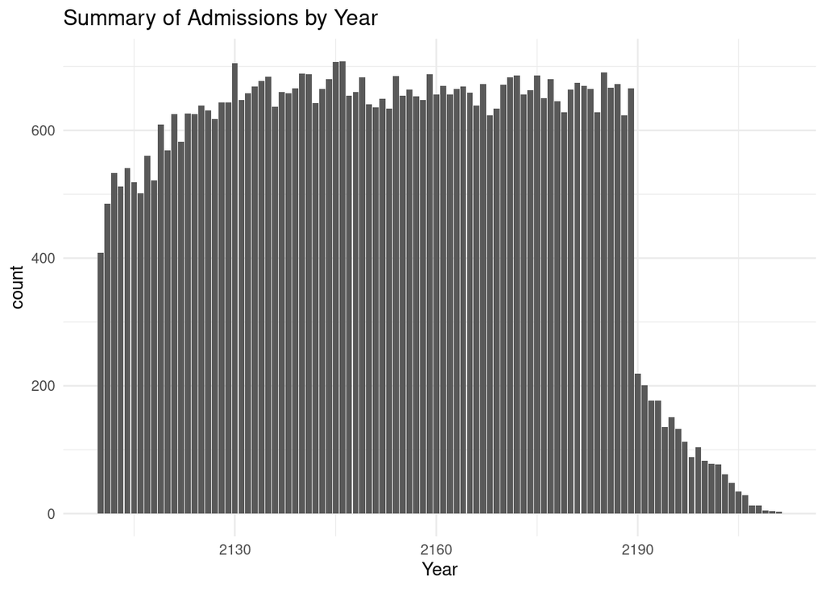

```r
#Admissions by year
ggplot(data = admissions_table, aes(x= year(admittime)))+ geom_bar() +
  ggtitle("Summary of Admissions by Year") + xlab("Year") + theme_minimal()
```

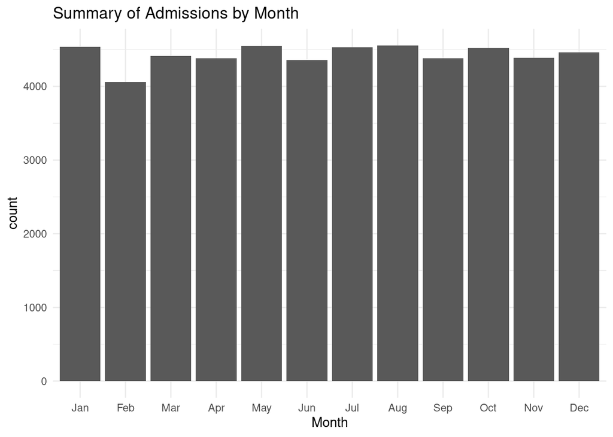

```r
#Admissions by month
ggplot(data = admissions_table, aes(x= month(admittime, label=TRUE)))+
  geom_bar() + ggtitle( "Summary of Admissions by Month")+xlab("Month") +
  theme_minimal();
```

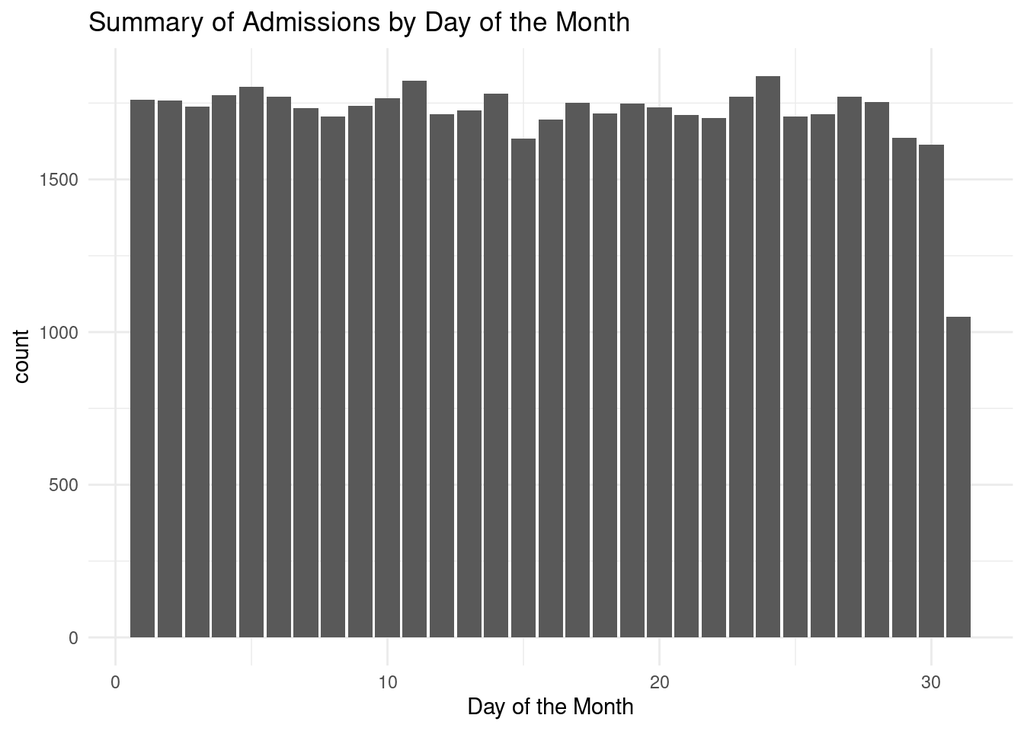

```r
#Admissions by day of the month
ggplot(data = admissions_table, aes(x= mday(admittime))) + geom_bar() +
  ggtitle("Summary of Admissions by Day of the Month") +
  xlab("Day of the Month")+theme_minimal()
```

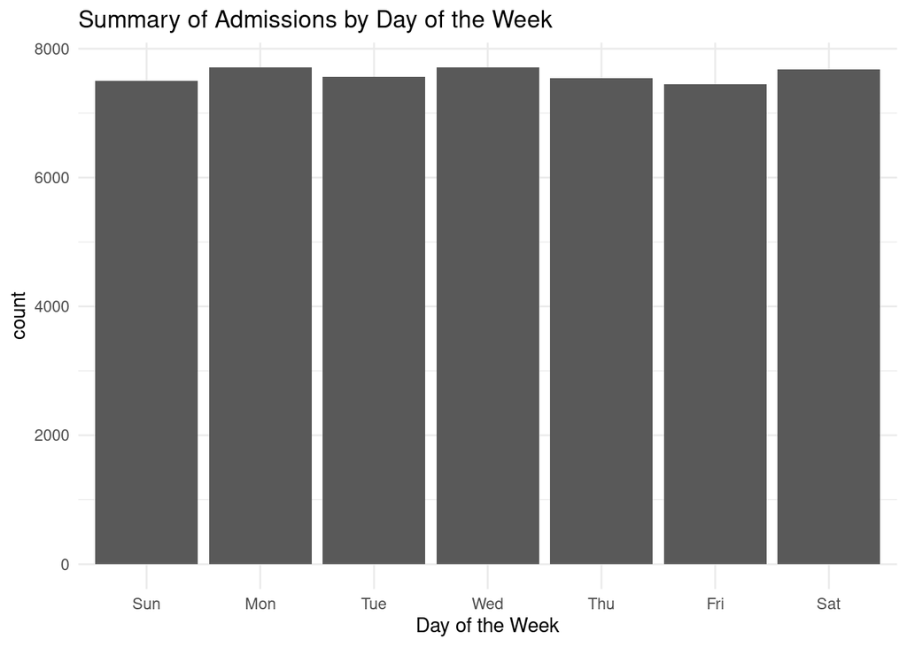

```r
#Admissions by day of the week
ggplot(data = admissions_table, aes(x= wday(admittime, label=T))) +
  geom_bar() + ggtitle("Summary of Admissions by Day of the Week") +
  xlab("Day of the Week") +
  theme_minimal()
```

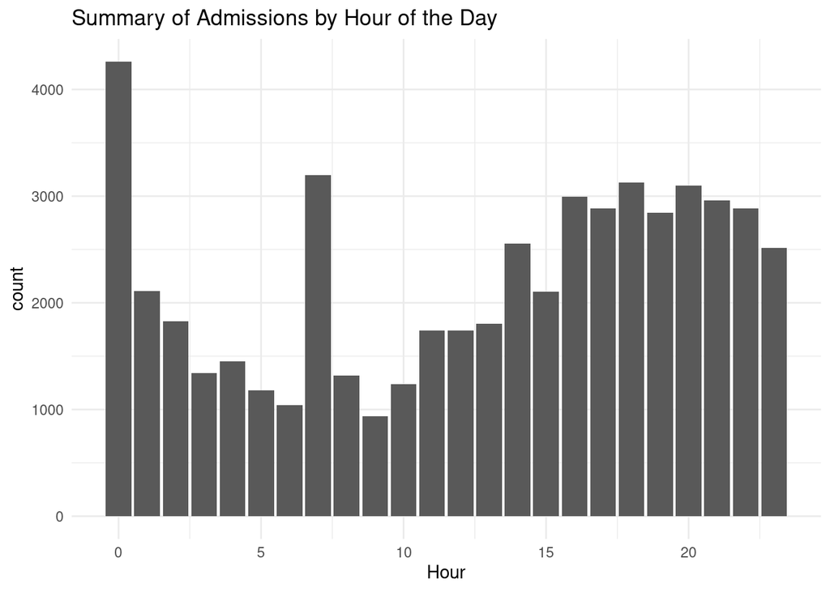

```r
#Admissions by hour
ggplot(data = admissions_table, aes(x= hour(admittime))) + geom_bar() +
  ggtitle("Summary of Admissions by Hour of the Day") + xlab("Hour") +
  theme_minimal()
```

There appears to be many admissions at midnight. We would probably expect that the number of admissions from 11 pm to 12 am and 12 am to 1 pm would not be so starkly different, but it might be due to input error.

## Q4. `patients` data

Patient information is available in `patients.csv.gz`. See https://mimic.mit.edu/docs/iv/modules/core/patients/ for details of each field in this file. The first 10 lines are

```r
system(
  str_c(
    "zcat < ",
    shQuote(str_c(mimic_path, "/core/patients.csv.gz")),
    " | head"
    ),
  intern = TRUE
)
```

```
##  [1] "subject_id,gender,anchor_age,anchor_year,anchor_year_group,dod"
##  [2] "10000048,F,23,2126,2008 - 2010,"
##  [3] "10002723,F,0,2128,2017 - 2019,"
##  [4] "10003939,M,0,2184,2008 - 2010,"
##  [5] "10004222,M,0,2161,2014 - 2016,"
##  [6] "10005325,F,0,2154,2011 - 2013,"
##  [7] "10007338,F,0,2153,2017 - 2019,"
##  [8] "10008101,M,0,2142,2008 - 2010,"
##  [9] "10009872,F,0,2168,2014 - 2016,"
## [10] "10011333,F,0,2132,2014 - 2016,"
```

1. Import `patients.csv.gz` (https://mimic.mit.edu/docs/iv/modules/core/patients/) as a tibble `patients_tble` and only keep the patients who have a match in `icustays_tble` (according to `subject_id`).
2. Summarize variables `gender` and `anchor_age`, and explain any patterns you see.

**Solution:** 1.

```r
patients_tble <- read_csv(str_c(mimic_path, "/core/patients.csv.gz")) %>%
  semi_join(icustays_tble, by = "subject_id")
patients_tble %>% summarise(n_male = sum(gender=="M"),
                            n_female = sum(gender =="F"),
                            avg_anchor_age = mean(anchor_age),
                            avg_M_age = mean(anchor_age[gender == "M"]),
                            avg_F_age = mean(anchor_age[gender == "F"]))
```

```
## # A tibble: 1 × 5
##   n_male n_female avg_anchor_age avg_M_age avg_F_age
##    <int>    <int>          <dbl>     <dbl>     <dbl>
## 1  29797    23353           63.5      62.5      64.8
```

## Q5. Lab results

`labevents.csv.gz` (https://mimic.mit.edu/docs/iv/modules/hosp/labevents/) contains all laboratory measurements for patients. The first 10 lines are

```r
system(
  str_c(
    "zcat < ",
    shQuote(str_c(mimic_path, "/hosp/labevents_filtered_itemid.csv.gz")),
    " | head"
    ),
  intern = TRUE
)
```

```
##  [1] "subject_id,itemid,charttime,valuenum"
##  [2] "10000048,50882,2126-11-22 20:45:00,26"
##  [3] "10000048,50902,2126-11-22 20:45:00,106"
##  [4] "10000048,50912,2126-11-22 20:45:00,0.7"
##  [5] "10000048,50931,2126-11-22 20:45:00,95"
##  [6] "10000048,50971,2126-11-22 20:45:00,4"
##  [7] "10000048,50983,2126-11-22 20:45:00,141"
##  [8] "10000048,51221,2126-11-22 20:45:00,38.2"
##  [9] "10000048,51301,2126-11-22 20:45:00,9.6"
## [10] "10000473,50882,2138-03-15 22:37:00,25"
```

`d_labitems.csv.gz` is the dictionary of lab measurements.

```r
system(
  str_c(
    "zcat < ",
    shQuote(str_c(mimic_path, "/hosp/d_labitems.csv.gz")),
    " | head"
    ),
  intern = TRUE
)
```

```
##  [1] "itemid,label,fluid,category,loinc_code"
##  [2] "51905, ,Other Body Fluid,Chemistry,"
##  [3] "51532,11-Deoxycorticosterone,Blood,Chemistry,"
##  [4] "51957,17-Hydroxycorticosteroids,Urine,Chemistry,"
##  [5] "51958,\"17-Ketosteroids, Urine\",Urine,Chemistry,"
##  [6] "52068,24 Hr,Blood,Hematology,"
##  [7] "51066,24 hr Calcium,Urine,Chemistry,"
##  [8] "51067,24 hr Creatinine,Urine,Chemistry,"
##  [9] "51068,24 hr Protein,Urine,Chemistry,"
## [10] "50853,25-OH Vitamin D,Blood,Chemistry,"
```

1. Find how many rows are in `labevents.csv.gz`.
2. We are interested in the lab measurements of creatinine (50912), potassium (50971), sodium (50983), chloride (50902), bicarbonate (50882), hematocrit (51221), white blood cell count (51301), glucose (50931), magnesium (50960), and calcium (50893). Retrieve a subset of `labevents.csv.gz` only containing these items for the patients in `icustays_tble` as a tibble `labevents_tble`.

   Hint: `labevents.csv.gz` is a data file too big to be read in by the `read_csv` function in its default setting. Utilize the `col_select` and `lazy` options in the `read_csv` function to reduce the memory burden.
3. Further restrict `labevents_tble` to the first lab measurement during the ICU stay.
4. Summarize the lab measurements by appropriate numerics and graphics.

**Solution:** Part 1:

```r
lab_events_tble <- read_csv(str_c(
  mimic_path, "/hosp/labevents_filtered_itemid.csv.gz"))
num_rows <- dim(lab_events_tble)[1]; num_rows
```

```
## [1] 30198826
```

Part 2:

```r
labevents_tble <- lab_events_tble %>%
  filter(itemid %in% c(50912, 50971, 50983, 50902, 50882, 51221,
                       51301, 50931, 50960, 50893))
```

Part 3:

```r
labevents_tble <- labevents_tble %>%  group_by(subject_id) %>%
  slice_min(n = 1, order_by = as.numeric(charttime))
```

Part 4:

```r
lab_meas <- labevents_tble %>%
 pivot_wider(names_from = itemid, values_from = valuenum, values_fn = {min})
colnames(lab_meas)[3:12] <- c("hematocrit", "wbc_count", "bicarbonate", "calcium",
                           "chloride", "creatinine", "magnesium", "potassium",
                           "sodium", "glucose")
```

```r
labevents_tble %>% group_by(itemid) %>% summarise(mean = mean(na.omit(valuenum)),
                                                  sd = sd(na.omit(valuenum)),
                                                  min = min(na.omit(valuenum)),
                                                  max = max(na.omit(valuenum)))
```

```
## # A tibble: 10 × 5
##    itemid   mean     sd   min     max
##     <dbl>  <dbl>  <dbl> <dbl>   <dbl>
##  1  50882  25.3   3.55    2      50
##  2  50893   9.21  0.758   0      30
##  3  50902 102.    4.07   46     140
##  4  50912   1.02  1.88    0     808
##  5  50931 117.   56.8     6    2340
##  6  50960   2.02  0.341   0      32
##  7  50971   4.19  0.636   1.3    10.4
##  8  50983 139.    3.52   96     180
##  9  51221  39.7   5.80    0      77.5
## 10  51301   9.43 25.2     0.1 12000
```

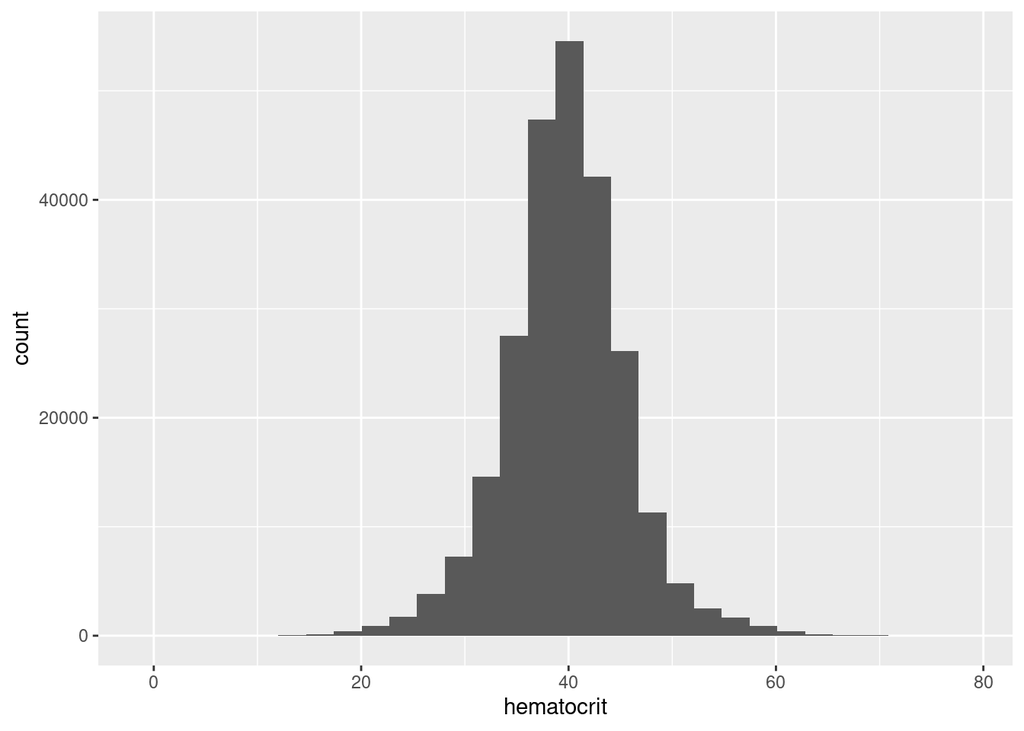

```r
ggplot(lab_meas, aes(x=hematocrit))+ geom_histogram()
```

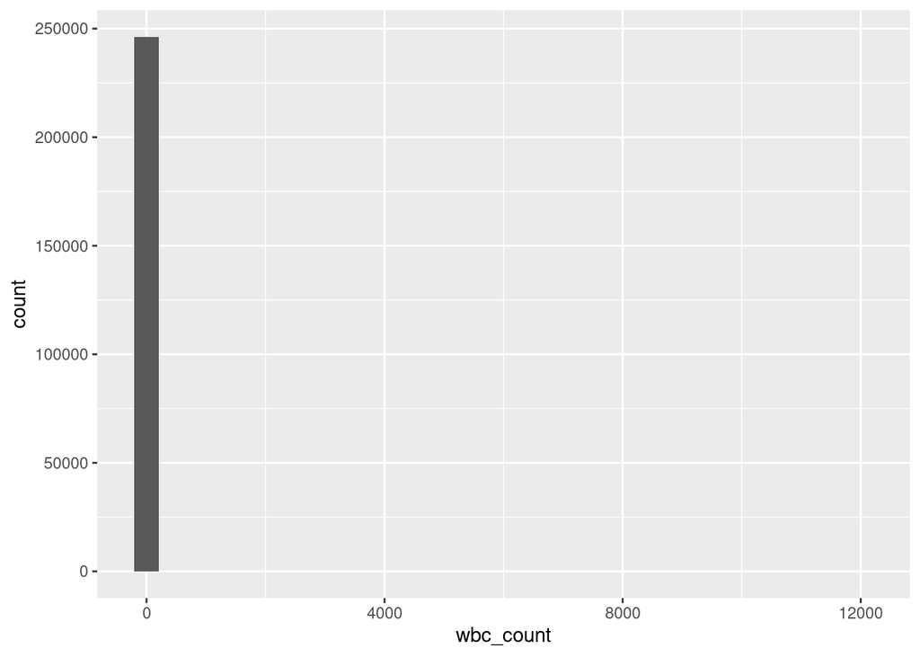

```r
ggplot(lab_meas, aes(x=wbc_count))+ geom_histogram()
```

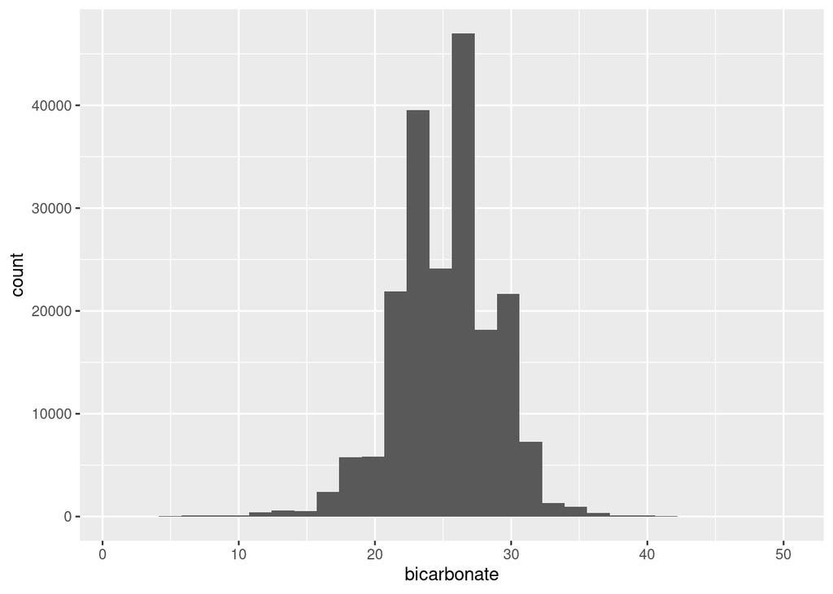

```r
ggplot(lab_meas, aes(x=bicarbonate))+ geom_histogram()
```

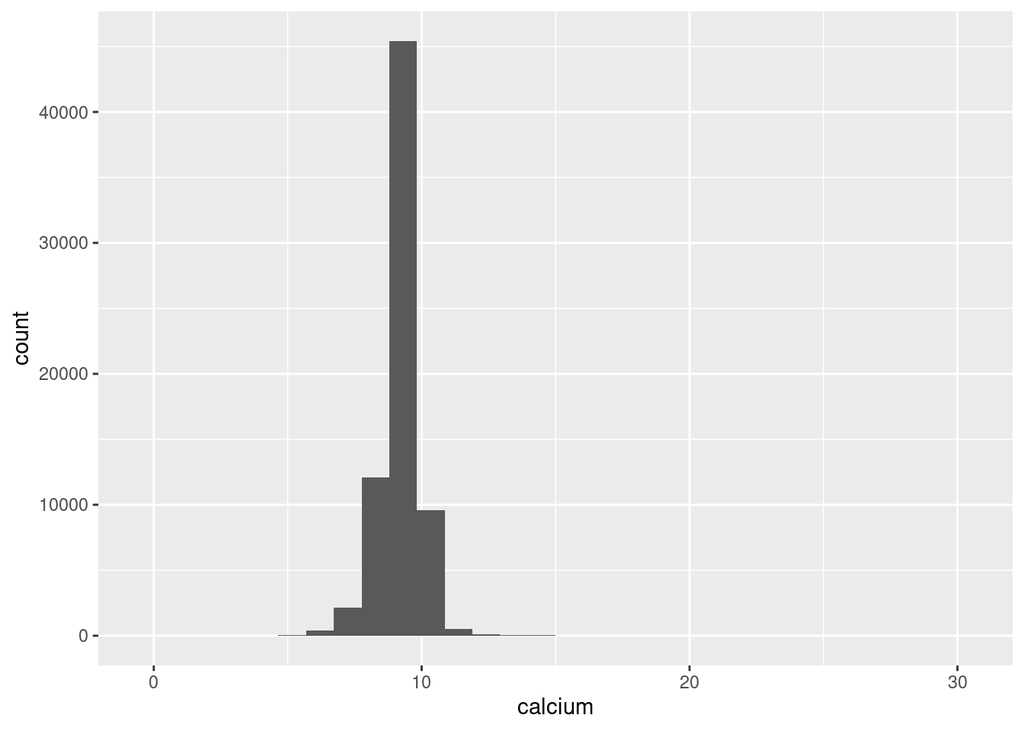

```r
ggplot(lab_meas, aes(x=calcium))+ geom_histogram()
```

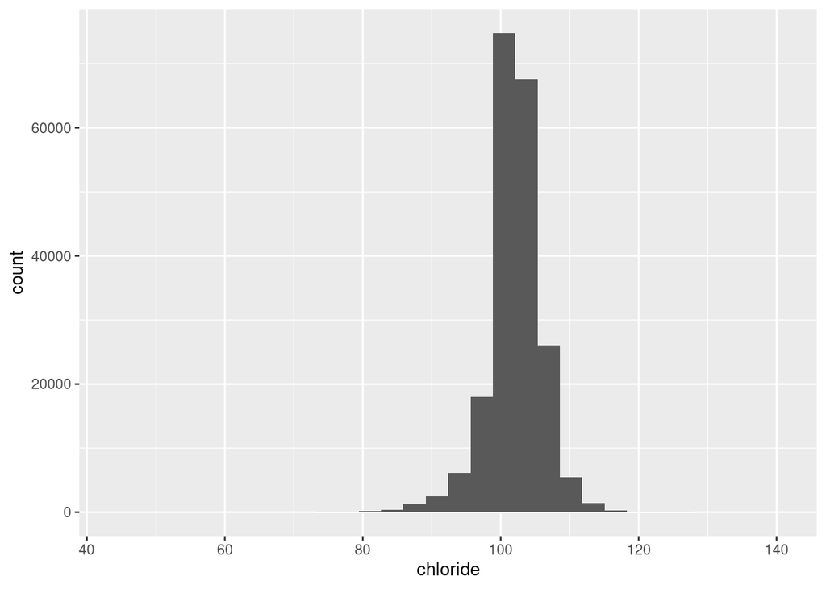

```r
ggplot(lab_meas, aes(x=chloride))+ geom_histogram()
```

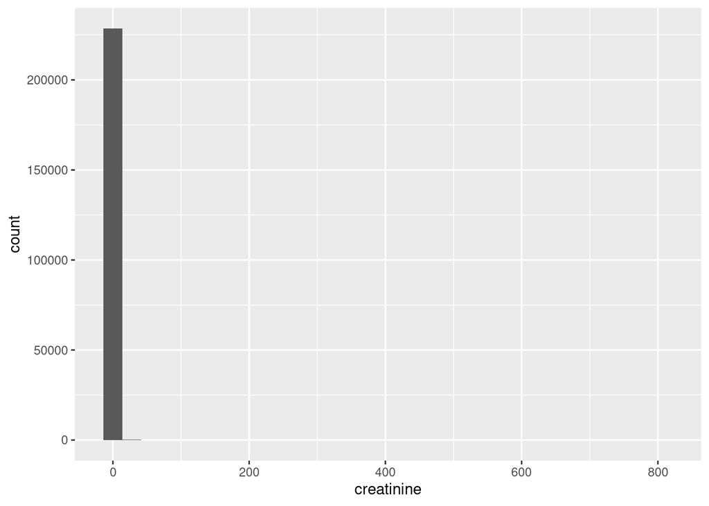

```r
ggplot(lab_meas, aes(x=creatinine))+ geom_histogram()
```

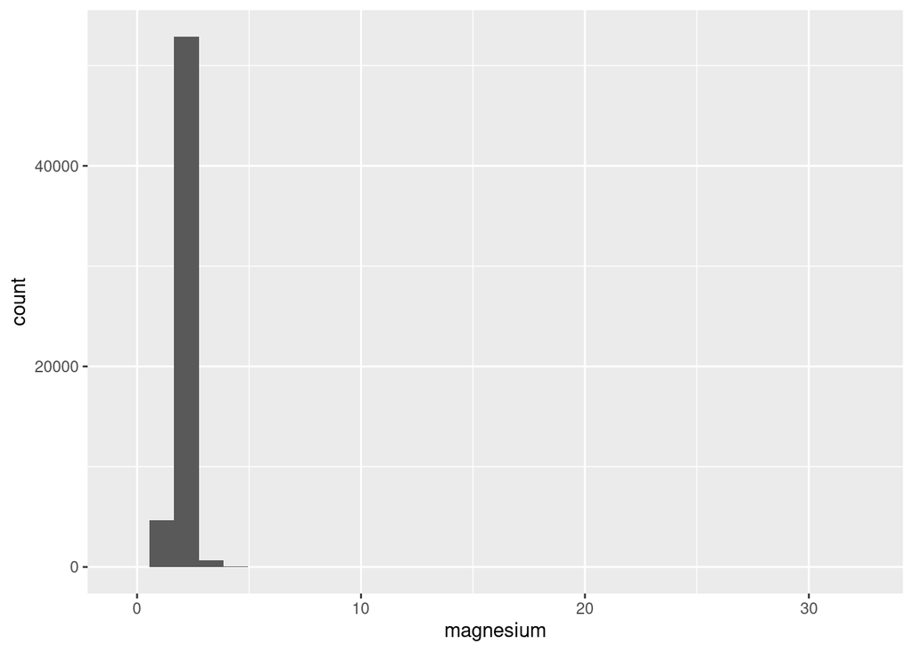

```r
ggplot(lab_meas, aes(x=magnesium))+ geom_histogram()
```

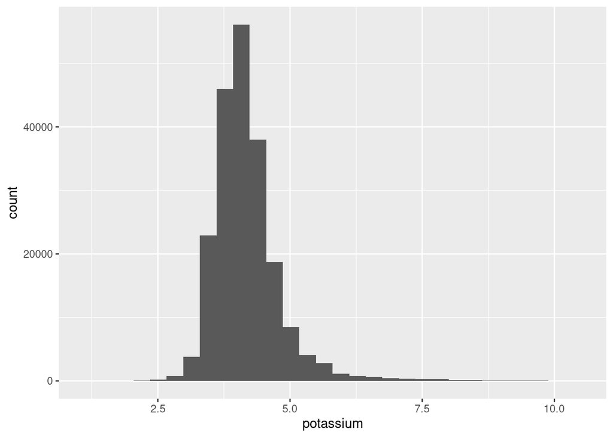

```r
ggplot(lab_meas, aes(x=potassium))+ geom_histogram()
```

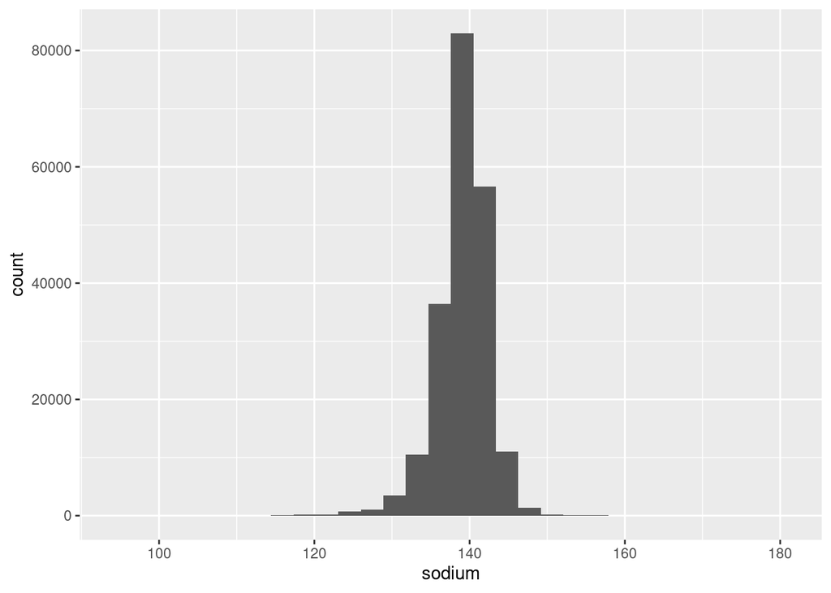

```r
ggplot(lab_meas, aes(x=sodium))+ geom_histogram()
```

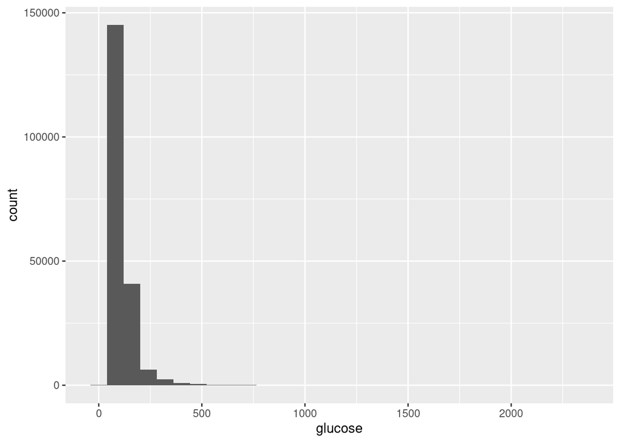

```r
ggplot(lab_meas, aes(x=glucose))+ geom_histogram()
```

## Q6. Vitals from charted events

`chartevents.csv.gz` (https://mimic.mit.edu/docs/iv/modules/icu/chartevents/) contains all the charted data available for a patient. During their ICU stay, the primary repository of a patient’s information is their electronic chart. The `itemid` variable indicates a single measurement type in the database. The `value` variable is the value measured for `itemid`. The first 10 lines of `chartevents.csv.gz` are

```r
system(
  str_c(
    "zcat < ",
    shQuote(str_c(mimic_path, "/icu/chartevents_filtered_itemid.csv.gz")),
    " | head"),
  intern = TRUE
)
```

```
##  [1] "subject_id,hadm_id,stay_id,charttime,itemid,valuenum"
##  [2] "10003700,28623837,30600691,2165-04-24 05:28:00,220179,152"
##  [3] "10003700,28623837,30600691,2165-04-24 05:28:00,220181,110"
##  [4] "10003700,28623837,30600691,2165-04-24 05:30:00,220045,65"
##  [5] "10003700,28623837,30600691,2165-04-24 05:30:00,220210,14"
##  [6] "10003700,28623837,30600691,2165-04-24 05:38:00,223761,97.6"
##  [7] "10003700,28623837,30600691,2165-04-24 06:00:00,220045,56"
##  [8] "10003700,28623837,30600691,2165-04-24 06:00:00,220179,126"
##  [9] "10003700,28623837,30600691,2165-04-24 06:00:00,220181,88"
## [10] "10003700,28623837,30600691,2165-04-24 06:00:00,220210,14"
```

`d_items.csv.gz` (https://mimic.mit.edu/docs/iv/modules/icu/d_items/) is the dictionary for the `itemid` in `chartevents.csv.gz`.

```r
system(
  str_c(
    "zcat < ",
    shQuote(str_c(mimic_path, "/icu/d_items.csv.gz")),
    " | head"),
  intern = TRUE
)
```

```
##  [1] "itemid,label,abbreviation,linksto,category,unitname,param_type,lownormalvalue,highnormalvalue"
##  [2] "220003,ICU Admission date,ICU Admission date,datetimeevents,ADT,,Date and time,,"
##  [3] "220045,Heart Rate,HR,chartevents,Routine Vital Signs,bpm,Numeric,,"
##  [4] "220046,Heart rate Alarm - High,HR Alarm - High,chartevents,Alarms,bpm,Numeric,,"
##  [5] "220047,Heart Rate Alarm - Low,HR Alarm - Low,chartevents,Alarms,bpm,Numeric,,"
##  [6] "220048,Heart Rhythm,Heart Rhythm,chartevents,Routine Vital Signs,,Text,,"
##  [7] "220050,Arterial Blood Pressure systolic,ABPs,chartevents,Routine Vital Signs,mmHg,Numeric,90,140"
##  [8] "220051,Arterial Blood Pressure diastolic,ABPd,chartevents,Routine Vital Signs,mmHg,Numeric,60,90"
##  [9] "220052,Arterial Blood Pressure mean,ABPm,chartevents,Routine Vital Signs,mmHg,Numeric,,"
## [10] "220056,Arterial Blood Pressure Alarm - Low,ABP Alarm - Low,chartevents,Alarms,mmHg,Numeric,,"
```

1. We are interested in the vitals for ICU patients: heart rate (220045), mean non-invasive blood pressure (220181), systolic non-invasive blood pressure (220179), body temperature in Fahrenheit (223761), and respiratory rate (220210). Retrieve a subset of `chartevents.csv.gz` only containing these items for the patients in `icustays_tble` as a tibble `chartevents_tble`.
2. Further restrict `chartevents_tble` to the first vital measurement during the ICU stay.
3. Summarize these vital measurements by appropriate numerics and graphics.

**Solution:** 1.

```r
chartevents_tble <- read_csv(str_c(mimic_path, "/icu/chartevents_filtered_itemid.csv.gz")) %>%
  filter(itemid %in% c(220045, 220181, 220179, 223761, 220210))
chartevents_tble <- chartevents_tble %>% group_by(subject_id) %>%
  slice_min(n = 1, order_by = as.numeric(charttime))
```

```r
vitals <- chartevents_tble %>%
  pivot_wider(names_from = itemid, values_from = valuenum)
colnames(vitals)[5:9] <- c("temp_far", "resp_rate", "heart_rate", "syst_bp",
                           "mean_bp" )
```

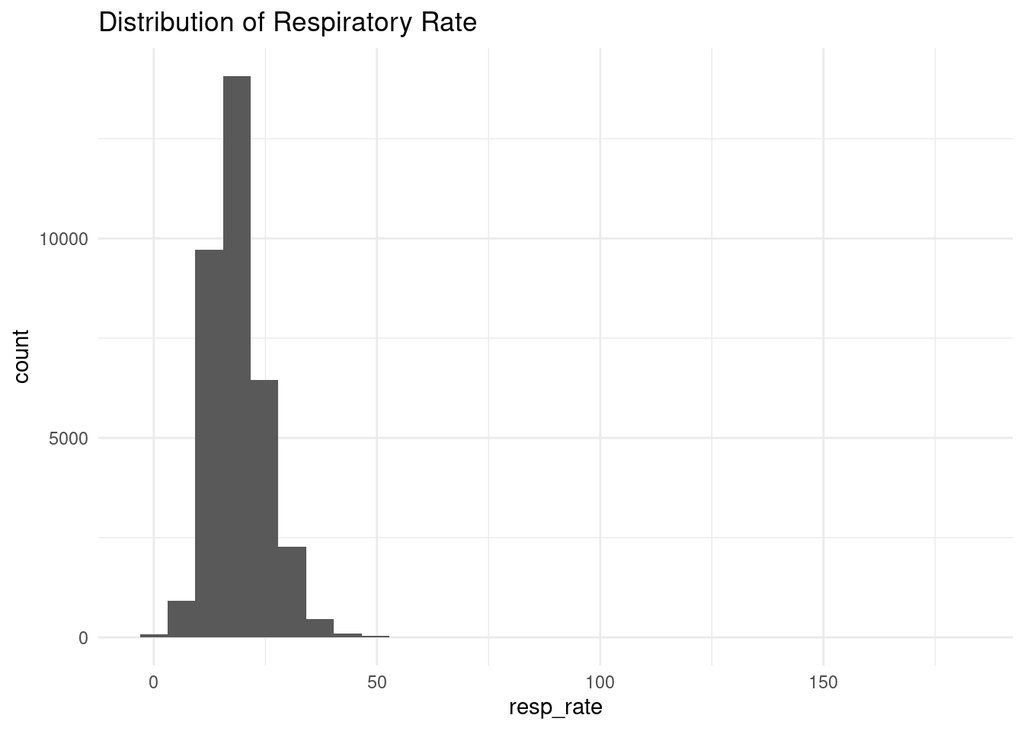

```r
ggplot(vitals, aes(x=resp_rate)) +
  geom_histogram()+ggtitle("Distribution of Respiratory Rate")+
  theme_minimal()
```

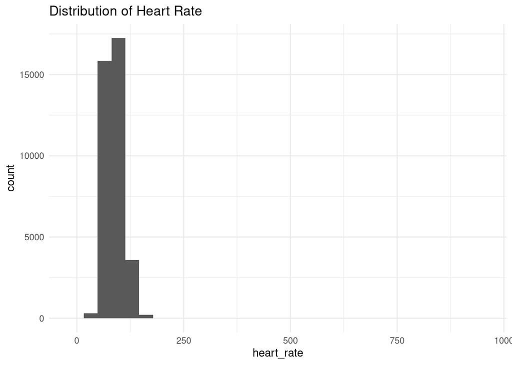

```r
ggplot(vitals, aes(x=heart_rate)) +
  geom_histogram()+ggtitle("Distribution of Heart Rate")+
  theme_minimal()
```

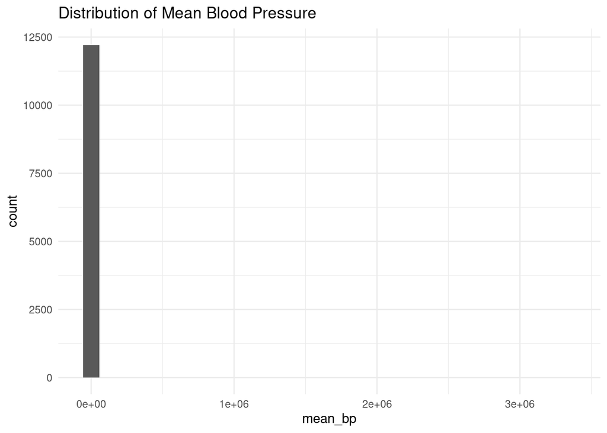

```r
ggplot(vitals, aes(x=mean_bp)) +
  geom_histogram()+ggtitle("Distribution of Mean Blood Pressure")+
  theme_minimal()
```

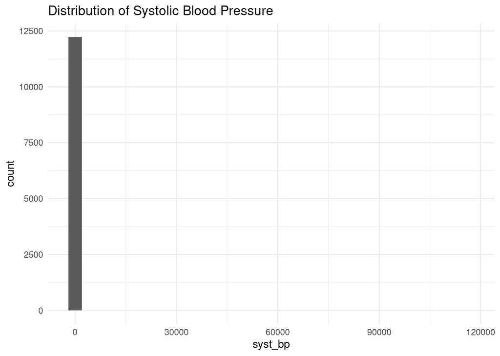

```r
ggplot(vitals, aes(x=syst_bp)) +
  geom_histogram()+ggtitle("Distribution of Systolic Blood Pressure")+
  theme_minimal()
```

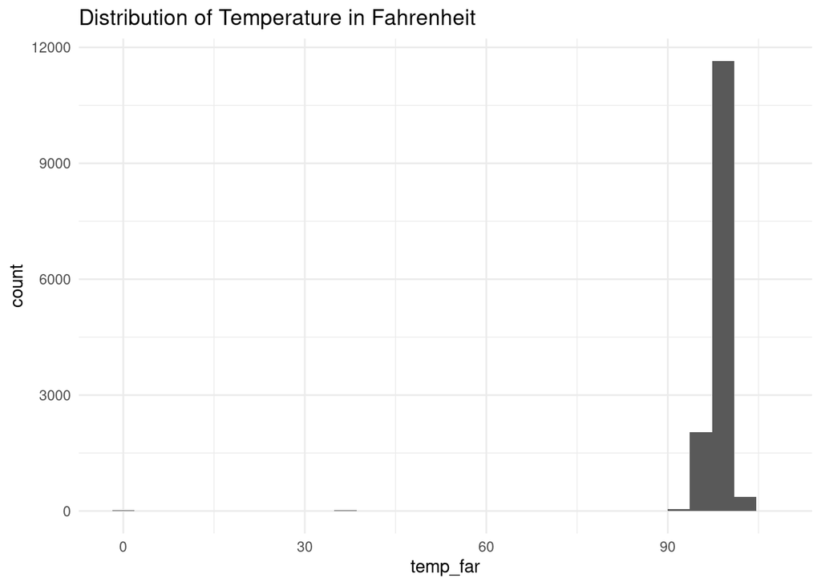

```r
ggplot(vitals, aes(x=temp_far)) +
  geom_histogram()+ggtitle("Distribution of Temperature in Fahrenheit")+
  theme_minimal()
```

## Q7. Putting things together

Let us create a tibble `mimic_icu_cohort` for all ICU stays, where rows are

- first ICU stay of each unique adult (age at admission > 18)

and columns contain at least following variables

- all variables in `icustays.csv.gz`
- all variables in `admission.csv.gz`
- all variables in `patients.csv.gz`
- first lab measurements during ICU stay
- first vital measurements during ICU stay
- an indicator variable `thirty_day_mort` whether the patient died within 30 days of hospital admission (30 day mortality)

**Solution:**

```r
#all variables in the three tables
mimic_icu_cohort <- icustays_tble %>%
  inner_join(admissions_table, by = c("subject_id", "hadm_id"))  %>%
  inner_join(patients_tble, by = "subject_id") %>%
  filter(anchor_age >= 18)


head(mimic_icu_cohort)
```

```
## # A tibble: 6 × 26
## # Groups:   subject_id [6]
##   subject_id  hadm_id  stay_id first_careunit last_careunit intime outtime   los
##        <dbl>    <dbl>    <int> <fct>          <fct>         <fct>  <fct>   <dbl>
## 1   10000032 29079034 39553978 Medical Inten… Medical Inte… 2180-… 2180-0… 0.410
## 2   10000980 26913865 39765666 Medical Inten… Medical Inte… 2189-… 2189-0… 0.498
## 3   10001217 24597018 37067082 Surgical Inte… Surgical Int… 2157-… 2157-1… 1.12
## 4   10001725 25563031 31205490 Medical/Surgi… Medical/Surg… 2110-… 2110-0… 1.34
## 5   10001884 26184834 37510196 Medical Inten… Medical Inte… 2131-… 2131-0… 9.17
## 6   10002013 23581541 39060235 Cardiac Vascu… Cardiac Vasc… 2160-… 2160-0… 1.31
## # … with 18 more variables: admittime <dttm>, dischtime <dttm>,
## #   deathtime <dttm>, admission_type <chr>, admission_location <chr>,
## #   discharge_location <chr>, insurance <chr>, language <chr>,
## #   marital_status <chr>, ethnicity <chr>, edregtime <dttm>, edouttime <dttm>,
## #   hospital_expire_flag <dbl>, gender <chr>, anchor_age <dbl>,
## #   anchor_year <dbl>, anchor_year_group <chr>, dod <date>
```

```r
#adding first lab measurements
mimic_icu_cohort <- mimic_icu_cohort %>%
  inner_join(lab_meas, by = "subject_id") %>%
  inner_join(vitals, by = "subject_id")

head(mimic_icu_cohort)
```

```
## # A tibble: 6 × 45
## # Groups:   subject_id [6]
##   subject_id hadm_id.x stay_id.x first_careunit   last_careunit   intime outtime
##        <dbl>     <dbl>     <int> <fct>            <fct>           <fct>  <fct>
## 1   10000032  29079034  39553978 Medical Intensi… Medical Intens… 2180-… 2180-0…
## 2   10000980  26913865  39765666 Medical Intensi… Medical Intens… 2189-… 2189-0…
## 3   10001217  24597018  37067082 Surgical Intens… Surgical Inten… 2157-… 2157-1…
## 4   10001725  25563031  31205490 Medical/Surgica… Medical/Surgic… 2110-… 2110-0…
## 5   10001884  26184834  37510196 Medical Intensi… Medical Intens… 2131-… 2131-0…
## 6   10002013  23581541  39060235 Cardiac Vascula… Cardiac Vascul… 2160-… 2160-0…
## # … with 38 more variables: los <dbl>, admittime <dttm>, dischtime <dttm>,
## #   deathtime <dttm>, admission_type <chr>, admission_location <chr>,
## #   discharge_location <chr>, insurance <chr>, language <chr>,
## #   marital_status <chr>, ethnicity <chr>, edregtime <dttm>, edouttime <dttm>,
## #   hospital_expire_flag <dbl>, gender <chr>, anchor_age <dbl>,
## #   anchor_year <dbl>, anchor_year_group <chr>, dod <date>, charttime.x <dttm>,
## #   hematocrit <dbl>, wbc_count <dbl>, bicarbonate <dbl>, calcium <dbl>, …
```

```r
#adding the 30-day mortality column
mimic_icu_cohort$thirty_day_mort <-
  as.numeric((ymd_hms(mimic_icu_cohort$deathtime) - ymd_hms(mimic_icu_cohort$admittime)) <= 30*60*24)
```

## Q8. Exploratory data analysis (EDA)

Summarize following information using appropriate numerics or graphs.

- `thirty_day_mort` vs demographic variables (ethnicity, language, insurance, marital_status, gender, age at hospital admission)
- `thirty_day_mort` vs first lab measurements
- `thirty_day_mort` vs first vital measurements
- `thirty_day_mort` vs first ICU unit

**Solution:**

```r
mimic_icu_cohort %>%
  group_by(ethnicity) %>%
  summarise(numdeaths = sum(na.omit(thirty_day_mort)))
```

```
## # A tibble: 8 × 2
##   ethnicity                     numdeaths
##   <chr>                             <dbl>
## 1 AMERICAN INDIAN/ALASKA NATIVE         7
## 2 ASIAN                               161
## 3 BLACK/AFRICAN AMERICAN              379
## 4 HISPANIC/LATINO                     114
## 5 OTHER                               211
## 6 UNABLE TO OBTAIN                    120
## 7 UNKNOWN                            1130
## 8 WHITE                              3072
```

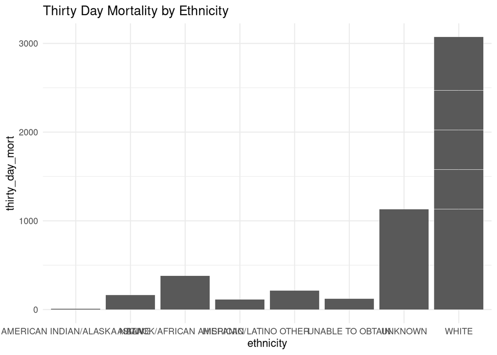

```r
ggplot(mimic_icu_cohort, aes(x = ethnicity, y = thirty_day_mort)) +
  geom_col() + ggtitle("Thirty Day Mortality by Ethnicity") +
  theme_minimal()
```

```r
mimic_icu_cohort %>%
  group_by(language) %>%
  summarise(numdeaths = sum(na.omit(thirty_day_mort)))
```

```
## # A tibble: 2 × 2
##   language numdeaths
##   <chr>        <dbl>
## 1 ?              558
## 2 ENGLISH       4636
```

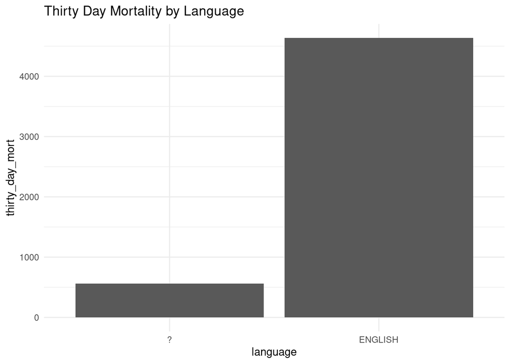

```r
ggplot(mimic_icu_cohort, aes(x = language, y = thirty_day_mort)) +
  geom_col() + ggtitle("Thirty Day Mortality by Language") +
  theme_minimal()
```

```r
mimic_icu_cohort %>%
  group_by(insurance) %>%
  summarise(numdeaths = sum(na.omit(thirty_day_mort)))
```

```
## # A tibble: 3 × 2
##   insurance numdeaths
##   <chr>         <dbl>
## 1 Medicaid        297
## 2 Medicare       2757
## 3 Other          2140
```

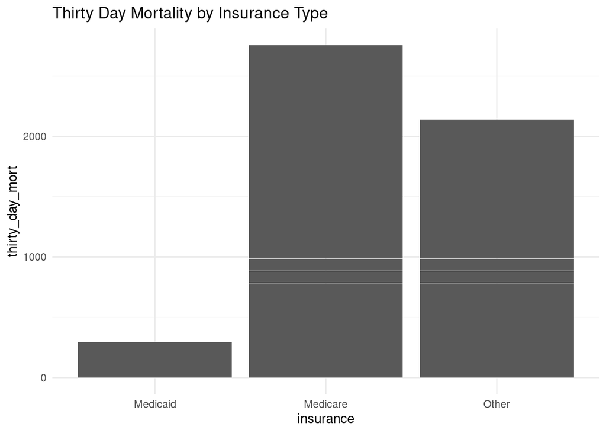

```r
ggplot(mimic_icu_cohort, aes(x = insurance, y = thirty_day_mort)) +
  geom_col() + ggtitle("Thirty Day Mortality by Insurance Type") +
  theme_minimal()
```

```r
mimic_icu_cohort %>%
  group_by(marital_status) %>%
  summarise(numdeaths = sum(na.omit(thirty_day_mort)))
```

```
## # A tibble: 5 × 2
##   marital_status numdeaths
##   <chr>              <dbl>
## 1 DIVORCED             295
## 2 MARRIED             2041
## 3 SINGLE               998
## 4 WIDOWED              839
## 5 <NA>                1021
```

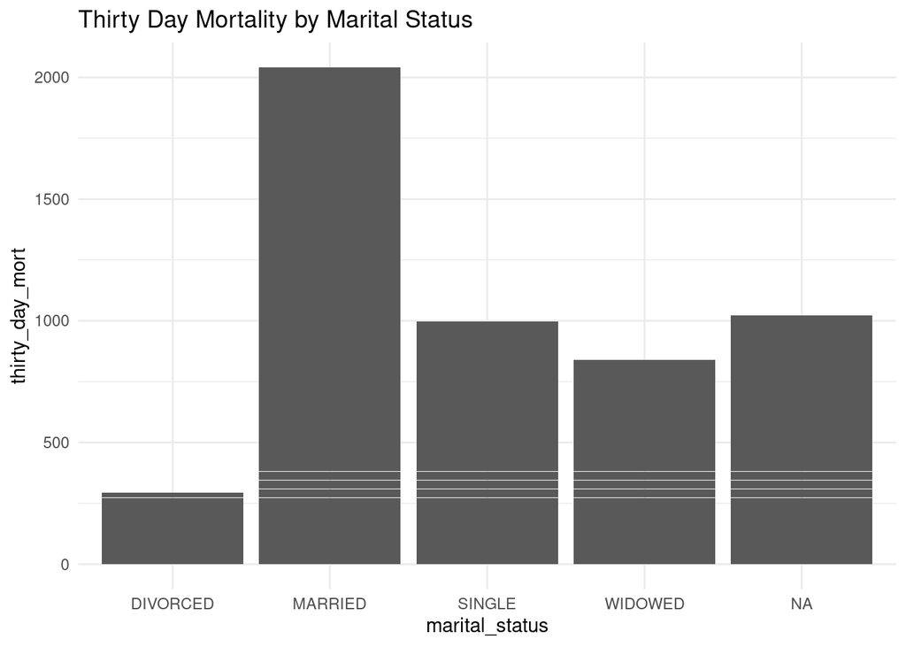

```r
ggplot(mimic_icu_cohort, aes(x = marital_status, y = thirty_day_mort)) +
  geom_col() + ggtitle("Thirty Day Mortality by Marital Status") +
  theme_minimal()
```

```r
mimic_icu_cohort %>%
  group_by(gender) %>%
  summarise(numdeaths = sum(na.omit(thirty_day_mort)))
```

```
## # A tibble: 2 × 2
##   gender numdeaths
##   <chr>      <dbl>
## 1 F           2401
## 2 M           2793
```

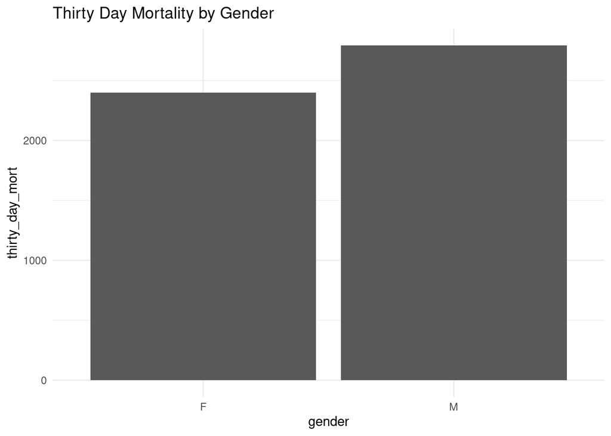

```r
ggplot(mimic_icu_cohort, aes(x = gender, y= thirty_day_mort)) + geom_col() +
  ggtitle("Thirty Day Mortality by Gender") + theme_minimal()
```

```r
mimic_icu_cohort %>%
  group_by(anchor_age) %>%
  summarise(numdeaths = sum(na.omit(thirty_day_mort)))
```

```
## # A tibble: 73 × 2
##    anchor_age numdeaths
##         <dbl>     <dbl>
##  1         18         1
##  2         19         6
##  3         20         7
##  4         21         3
##  5         22         7
##  6         23         6
##  7         24        10
##  8         25         9
##  9         26         9
## 10         27         5
## # … with 63 more rows
```

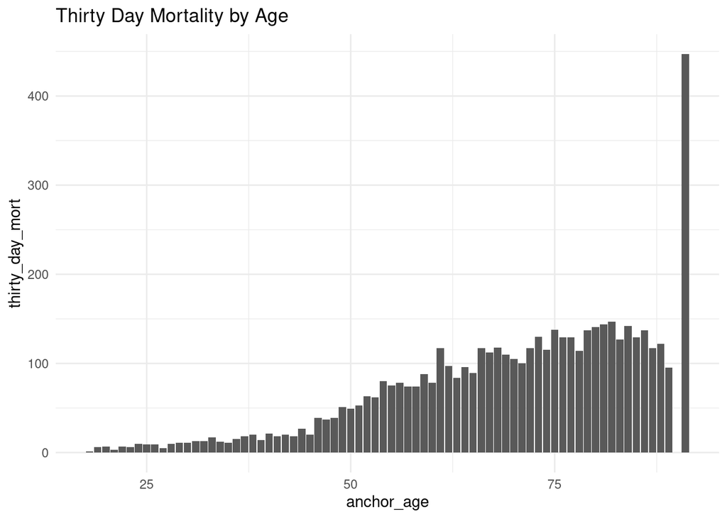

```r
ggplot(mimic_icu_cohort, aes(x = anchor_age, y = thirty_day_mort)) +
  geom_col() + ggtitle("Thirty Day Mortality by Age") +
  theme_minimal()
```

```r
#Table summarizing the average first lab measurements by thirty day mortality.
mimic_icu_cohort %>%
  group_by(thirty_day_mort) %>%
  summarise(mean_hematocrit = mean(na.omit(hematocrit)),
            mean_wbc_count = mean(na.omit(wbc_count)),
            mean_bicarbonate = mean(na.omit(bicarbonate)),
            mean_calcium = mean(na.omit(calcium)),
            mean_chloride = mean(na.omit(chloride)),
            mean_creatinine = mean(na.omit(creatinine)),
            mean_magnesium = mean(na.omit(magnesium)),
            mean_potassium = mean(na.omit(potassium)),
            mean_sodium = mean(na.omit(sodium)),
            mean_glucose = mean(na.omit(glucose))
  )
```

```
## # A tibble: 3 × 11
##   thirty_day_mort mean_hematocrit mean_wbc_count mean_bicarbonate mean_calcium
##             <dbl>           <dbl>          <dbl>            <dbl>        <dbl>
## 1               0            35.0           12.3             24.8         8.85
## 2               1            36.0           12.7             23.4         8.66
## 3              NA            37.8           10.2             24.8         8.91
## # … with 6 more variables: mean_chloride <dbl>, mean_creatinine <dbl>,
## #   mean_magnesium <dbl>, mean_potassium <dbl>, mean_sodium <dbl>,
## #   mean_glucose <dbl>
```

```r
#Table summarizing the average first vitals measurements by thirty day mortality.
mimic_icu_cohort %>%
  group_by(thirty_day_mort) %>%
  summarise(mean_temp = mean(na.omit(temp_far)),
            mean_resp_rate = mean(na.omit(resp_rate)),
            mean_heart_rate = mean(na.omit(heart_rate)),
            mean_syst_bp = mean(na.omit(syst_bp)),
            mean_avg_bp = mean(na.omit(mean_bp))
  )
```

```
## # A tibble: 3 × 6
##   thirty_day_mort mean_temp mean_resp_rate mean_heart_rate mean_syst_bp
##             <dbl>     <dbl>          <dbl>           <dbl>        <dbl>
## 1               0      97.0           21.0            96.7         116.
## 2               1      97.8           21.2            93.1         130.
## 3              NA      98.1           18.5            86.7         139.
## # … with 1 more variable: mean_avg_bp <dbl>
```

```r
#Table summarizing thirty day mortality by first ICU unit
mimic_icu_cohort %>%
  group_by(first_careunit) %>%
  summarise(thirty_day_mortality = sum(na.omit(thirty_day_mort)))
```

```
## # A tibble: 9 × 2
##   first_careunit                                   thirty_day_mortality
##   <fct>                                                           <dbl>
## 1 Cardiac Vascular Intensive Care Unit (CVICU)                      255
## 2 Coronary Care Unit (CCU)                                          714
## 3 Medical Intensive Care Unit (MICU)                               1379
## 4 Medical/Surgical Intensive Care Unit (MICU/SICU)                 1051
## 5 Neuro Intermediate                                                 27
## 6 Neuro Stepdown                                                     12
## 7 Neuro Surgical Intensive Care Unit (Neuro SICU)                   223
## 8 Surgical Intensive Care Unit (SICU)                               878
## 9 Trauma SICU (TSICU)                                               655
```

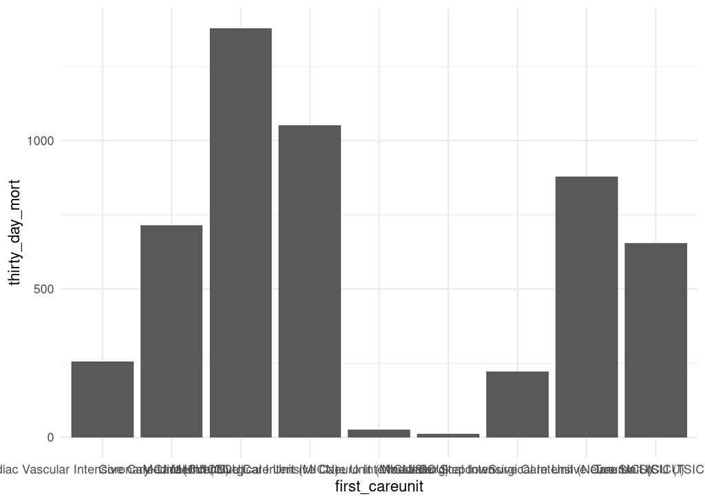

```r
ggplot(mimic_icu_cohort, aes(x = first_careunit, y = thirty_day_mort)) +
  geom_col() + theme_minimal()
```